# **CASE STUDY - SPORTS ANALYTICS (Steph Curry)**

#### This case study builds upon the analysis of the Steph Curry dataset, originally introduced in Chapter 15 of *Murach’s 'Python for Data Science'*. The objective is to extend the initial analysis by incorporating additional functions and substrings in order to conduct a deeper exploratory analysis and uncover new insights.

#### The four steps of the study, as given in the Exercise 15-1 on page 530, are:

##### 1. Get the data

##### 2. Clean the data

##### 3. Prepare and analyze the data

##### 4. Plot the data

### **1. Get the Data**,

#### Necessary modules:

```python
import pandas as pd
import seaborn as sns
import json
from urllib import request
```

#### Loading the json dataset into a dictionary and building a pandas dataframe:

```python
shots_url = 'https://www.murach.com/python_analysis/shots.json'
shots = request.urlretrieve(shots_url, filename='shots.json')

with open('shots.json') as jsonData:
    shots = json.load(jsonData)
shots.keys()    # displaying the dataset keys
```

```
dict_keys(['resource', 'parameters', 'resultSets'])
```

```python
columnHeaders = shots['resultSets'][0]['headers']   # building columns and rows
columnHeaders = [x.lower() for x in columnHeaders]
rows = shots['resultSets'][0]['rowSet']

shots = pd.DataFrame(data=rows, columns=columnHeaders)  # building the DataFrame
shots.head()  # the first five rows of the data frame
```

|  | grid_type | game_id | game_event_id | player_id | player_name | team_id | team_name | period | minutes_remaining | seconds_remaining | ... | shot_zone_area | shot_zone_range | shot_distance | loc_x | loc_y | shot_attempted_flag | shot_made_flag | game_date | htm | vtm |
| --- | --- | --- | --- | --- | --- | --- | --- | --- | --- | --- | --- | --- | --- | --- | --- | --- | --- | --- | --- | --- | --- |
| 0 | Shot Chart Detail | 0020900015 | 4 | 201939 | Stephen Curry | 1610612744 | Golden State Warriors | 1 | 11 | 25 | ... | Right Side Center(RC) | 24+ ft. | 26 | 99 | 249 | 1 | 0 | 20091028 | GSW | HOU |
| 1 | Shot Chart Detail | 0020900015 | 17 | 201939 | Stephen Curry | 1610612744 | Golden State Warriors | 1 | 9 | 31 | ... | Left Side Center(LC) | 16-24 ft. | 18 | -122 | 145 | 1 | 1 | 20091028 | GSW | HOU |
| 2 | Shot Chart Detail | 0020900015 | 53 | 201939 | Stephen Curry | 1610612744 | Golden State Warriors | 1 | 6 | 2 | ... | Center(C) | 8-16 ft. | 14 | -60 | 129 | 1 | 0 | 20091028 | GSW | HOU |
| 3 | Shot Chart Detail | 0020900015 | 141 | 201939 | Stephen Curry | 1610612744 | Golden State Warriors | 2 | 9 | 49 | ... | Left Side(L) | 16-24 ft. | 19 | -172 | 82 | 1 | 0 | 20091028 | GSW | HOU |
| 4 | Shot Chart Detail | 0020900015 | 249 | 201939 | Stephen Curry | 1610612744 | Golden State Warriors | 2 | 2 | 19 | ... | Left Side Center(LC) | 16-24 ft. | 16 | -68 | 148 | 1 | 0 | 20091028 | GSW | HOU |

5 rows × 24 columns

### **2. Clean the Data**

#### Drop columns that are not needed for the analysis:

```python
shots = shots.drop(columns=['grid_type','game_event_id','player_id','player_name',
                            'team_id','team_name','minutes_remaining','seconds_remaining',
                            'htm','vtm'])
```

```python
shots.head()  # verifying columns were dropped
```

|  | game_id | period | event_type | action_type | shot_type | shot_zone_basic | shot_zone_area | shot_zone_range | shot_distance | loc_x | loc_y | shot_attempted_flag | shot_made_flag | game_date |
| --- | --- | --- | --- | --- | --- | --- | --- | --- | --- | --- | --- | --- | --- | --- |
| 0 | 0020900015 | 1 | Missed Shot | Jump Shot | 3PT Field Goal | Above the Break 3 | Right Side Center(RC) | 24+ ft. | 26 | 99 | 249 | 1 | 0 | 20091028 |
| 1 | 0020900015 | 1 | Made Shot | Step Back Jump shot | 2PT Field Goal | Mid-Range | Left Side Center(LC) | 16-24 ft. | 18 | -122 | 145 | 1 | 1 | 20091028 |
| 2 | 0020900015 | 1 | Missed Shot | Jump Shot | 2PT Field Goal | In The Paint (Non-RA) | Center(C) | 8-16 ft. | 14 | -60 | 129 | 1 | 0 | 20091028 |
| 3 | 0020900015 | 2 | Missed Shot | Jump Shot | 2PT Field Goal | Mid-Range | Left Side(L) | 16-24 ft. | 19 | -172 | 82 | 1 | 0 | 20091028 |
| 4 | 0020900015 | 2 | Missed Shot | Jump Shot | 2PT Field Goal | Mid-Range | Left Side Center(LC) | 16-24 ft. | 16 | -68 | 148 | 1 | 0 | 20091028 |

#### Display the value counts for the period column:

```python
shots.period.value_counts()
```

```
period
3    3541
1    3501
2    2502
4    2209
5      90
6       3
Name: count, dtype: int64
```

#### Drop the rows for periods 5 and 6:

```python
shots = shots.query('period < 5')
shots.period.value_counts()
```

```
period
3    3541
1    3501
2    2502
4    2209
Name: count, dtype: int64
```

### **3. Prepare and Analyze the Data**

#### Display the number of unique values for the action_type column:

```python
shots.action_type.nunique()
```

```
51
```

#### Display the value counts for the action_type column:

```python
shots.action_type.value_counts()
```

```
action_type
Jump Shot                             5802
Pullup Jump shot                      1694
Step Back Jump shot                    755
Driving Layup Shot                     635
Layup Shot                             537
Floating Jump shot                     387
Driving Finger Roll Layup Shot         324
Running Jump Shot                      209
Driving Reverse Layup Shot             165
Running Layup Shot                     131
Cutting Layup Shot                     119
Jump Bank Shot                         108
Reverse Layup Shot                     102
Fadeaway Jump Shot                      90
Turnaround Jump Shot                    89
Driving Floating Jump Shot              83
Running Bank shot                       61
Running Finger Roll Layup Shot          51
Running Pull-Up Jump Shot               44
Finger Roll Layup Shot                  36
Driving Bank shot                       36
Driving Floating Bank Jump Shot         34
Running Reverse Layup Shot              33
Driving Jump shot                       32
Cutting Finger Roll Layup Shot          28
Turnaround Fadeaway shot                26
Pullup Bank shot                        20
Turnaround Bank shot                    20
Putback Layup Shot                      11
Hook Shot                               10
Running Hook Shot                       10
Driving Hook Shot                        9
Slam Dunk Shot                           7
Driving Dunk Shot                        7
Tip Shot                                 7
Tip Layup Shot                           6
Running Dunk Shot                        6
Dunk Shot                                5
Fadeaway Bank shot                       4
Turnaround Fadeaway Bank Jump Shot       3
Step Back Bank Jump Shot                 3
Turnaround Hook Shot                     3
Driving Slam Dunk Shot                   2
Jump Hook Shot                           2
Cutting Dunk Shot                        1
Driving Bank Hook Shot                   1
Alley Oop Layup shot                     1
Running Bank Hook Shot                   1
Hook Bank Shot                           1
Running Slam Dunk Shot                   1
Putback Dunk Shot                        1
Name: count, dtype: int64
```

#### Add substrings such as “Jump” and “Layup” to the list of common substrings that identify each action type. Then, continue to add substrings and to test this code until you’re sure that it provides all the values for the action_type column:

```python
commonSubstrings = ['Jump','Layup','Fadeaway','Hook','Tip','Dunk','Bank']
actions = shots[shots.action_type.str.contains('|'.join(commonSubstrings))].action_type.to_list()
shots.query('action_type not in @actions').action_type  # querying to ensure the list is empty and all values are provided
```

```
Series([], Name: action_type, dtype: object)
```

#### Define a function named get_label() that takes a row as input and loops through the common substrings list. In the loop, check if the substring is in the row’s action_type column. If so, return the substring:

```python
def get_label(row):
     for a in commonSubstrings:
         if a in row.action_type:
             return a
```

#### Apply this function to every row in the shots DataFrame and assign the result to the shot_type column:

```python
shots['shot_type'] = shots.apply(lambda x: get_label(x), axis=1)
```

```python
shots.shot_type.value_counts() # checking the shot_type column values
```

```
shot_type
Jump        9335
Layup       2179
Bank         137
Hook          35
Fadeaway      30
Dunk          30
Tip            7
Name: count, dtype: int64
```

### **4. Plot the Data**

#### Use Seaborn to create a count plot that shows the counts for each shot type:

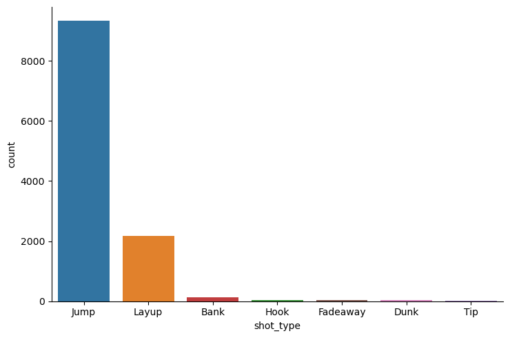

```python
sns.catplot(data=shots, kind='count', x='shot_type', hue = 'shot_type', order=shots['shot_type'].value_counts().index, aspect = 1.5)
```

#### Use the draw_court() function and the Seaborn displot() method to create a KDE plot with subplots for the “Jump” and “Layup” types:

```python
# SOURCE: http://savvastjortjoglou.com/nba-shot-sharts.html
from matplotlib.patches import Circle, Rectangle, Arc
def draw_court(ax=None, color='black', lw=2, outer_lines=False):
    # If an axes object isn't provided to plot onto, just get current one
    if ax is None:
        ax = plt.gca()

    # Create the various parts of an NBA basketball court

    # Create the basketball hoop
    # Diameter of a hoop is 18" so it has a radius of 9", which is a value
    # 7.5 in our coordinate system
    hoop = Circle((0, 0), radius=7.5, linewidth=lw, color=color, fill=False)

    # Create backboard
    backboard = Rectangle((-30, -7.5), 60, -1, linewidth=lw, color=color)

    # The paint
    # Create the outer box 0f the paint, width=16ft, height=19ft
    outer_box = Rectangle((-80, -47.5), 160, 190, linewidth=lw, color=color,
                          fill=False)
    # Create the inner box of the paint, widt=12ft, height=19ft
    inner_box = Rectangle((-60, -47.5), 120, 190, linewidth=lw, color=color,
                          fill=False)

    # Create free throw top arc
    top_free_throw = Arc((0, 142.5), 120, 120, theta1=0, theta2=180,
                         linewidth=lw, color=color, fill=False)
    # Create free throw bottom arc
    bottom_free_throw = Arc((0, 142.5), 120, 120, theta1=180, theta2=0,
                            linewidth=lw, color=color, linestyle='dashed')
    # Restricted Zone, it is an arc with 4ft radius from center of the hoop
    restricted = Arc((0, 0), 80, 80, theta1=0, theta2=180, linewidth=lw,
                     color=color)

    # Three point line
    # Create the side 3pt lines, they are 14ft long before they begin to arc
    corner_three_a = Rectangle((-220, -47.5), 0, 140, linewidth=lw,
                               color=color)
    corner_three_b = Rectangle((220, -47.5), 0, 140, linewidth=lw, color=color)
    # 3pt arc - center of arc will be the hoop, arc is 23'9" away from hoop
    # I just played around with the theta values until they lined up with the
    # threes
    three_arc = Arc((0, 0), 475, 475, theta1=22, theta2=158, linewidth=lw,
                    color=color)

    # Center Court
    center_outer_arc = Arc((0, 422.5), 120, 120, theta1=180, theta2=0,
                           linewidth=lw, color=color)
    center_inner_arc = Arc((0, 422.5), 40, 40, theta1=180, theta2=0,
                           linewidth=lw, color=color)

    # List of the court elements to be plotted onto the axes
    court_elements = [hoop, backboard, outer_box, inner_box, top_free_throw,
                      bottom_free_throw, restricted, corner_three_a,
                      corner_three_b, three_arc, center_outer_arc,
                      center_inner_arc]

    if outer_lines:
        # Draw the half court line, baseline and side out bound lines
        outer_lines = Rectangle((-250, -47.5), 500, 470, linewidth=lw,
                                color=color, fill=False)
        court_elements.append(outer_lines)

    # Add the court elements onto the axes
    for element in court_elements:
        ax.add_patch(element)

    return ax
```

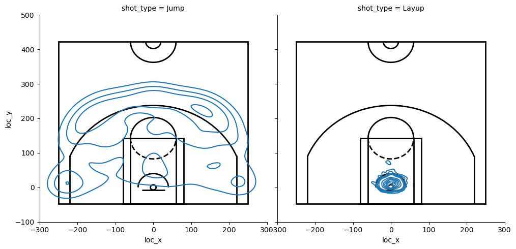

```python
# KDE plot of Steph Curry's 'Jump' and 'Layup" shots

graph = sns.displot(data=shots.query('shot_type in ["Jump","Layup"]'), kind='kde', x='loc_x', y='loc_y', col='shot_type', col_wrap=2)

for i, ax in enumerate(graph.axes.flat):
    ax = draw_court(ax, outer_lines=True)
    ax.set_xlim(-300,300)
    ax.set_ylim(-100, 500)
```